# Replication of Study 3 by Maddux et al. (2008, Personality and Social Psychology Bulletin)

Catherine Qing (caqing@stanford.edu)

December 11, 2022

## Introduction

This paper reports 4 experiments that explore realistic threat as a psychological mechanism that can explain how people can have positive stereotypical beliefs toward Asian Americans, yet express negative attitudes and emotions toward them. Although Asian Americans are typically perceived as a “model minority” that is educationally and economically successful, negative attitudes and emotions may arise from these positive stereotypes because of the belief that Asian Americans pose a realistic threat to other groups’ success and/or status. I am replicating Study 3, in particular, which demonstrated that experimentally inducing realistic threat caused negative attitude and affect toward Asian Americans.

### Justification

My research area of interest is stereotypes and bias, and I am particularly interested in racial stereotypes and their relation to prejudice. However, despite this, I have not yet gotten the opportunity to study Asian American stereotypes. As a result, I hope to use the skills I’ve developed through previous work I’ve done on projects involving Black stereotypes and prejudice and apply them to a research question centered on another racial group. In addition, Asian Americans remain a relatively understudied group in social psychology, so I believe it is important to attempt to replicate a study highlighting the negative effects of stereotypes associated with the model minority myth.

### Important Links

View the Github repository: [Project Repo](https://github.com/psych251/maddux2008)

View the original paper: [Maddux et al., 2008](https://github.com/psych251/maddux2008/blob/main/original_paper/maddux%20et%20al%202008.pdf)

## Methods

### Power Analysis

The original study did not report effect size, so I utilized G*Power to conduct a power analysis for a one-way ANOVA. This power analysis indicated that I would need a sample size of 54 participants to detect an effect size of 0.5. However, as shown below, I also conducted a power analysis for 80% power for a two-sample t-test (which should be the same) to detect an effect size of 0.5, but this power analysis suggested 64 participants for each condition.

```r
library(effectsize)
library(pwr)

pwr.t.test(n= NULL, d = 0.5, sig.level = 0.05, power = 0.8, type = "two.sample")
```

```
##
##      Two-sample t test power calculation
##
##               n = 63.76561
##               d = 0.5
##       sig.level = 0.05
##           power = 0.8
##     alternative = two.sided
##
## NOTE: n is number in *each* group
```

### Materials

The original experiment did not specify if data was collected online or in-person, as well as the platform on which the data was collected. This replication will utilize a Qualtrics survey that is expected to take each participant a maximum of 5 minutes to complete. The survey can be viewed at [this link](https://stanforduniversity.qualtrics.com/jfe/form/SV_9ErYeyIoqaKw08C).

### Procedure

Procedure was exactly the same as in the original experiment. The procedure description from Maddux et al. (2008) is quoted below.

> “Participants were told they would be participating in a series of unrelated experiments. The first experiment involved the experimental manipulation of realistic threat, which was followed by a filler task, and then an assessment of global attitudes and emotions toward Asian Americans. In the first phase of the experiment, participants were instructed to read a scenario and told that they would be answering questions about it later. The hypothetical scenario involved a project in a chemistry class, a class consistent with the stereotype of Asian Americans doing well in science classes (e.g., Kao, 2000). In addition, the class demographics were explicitly presented as being predominantly Asian American. Two experimental conditions were created, and participants were randomly assigned to one of two conditions. The instructions read as follows: You are assigned a project in your Chemistry class. Your professor has said the project will be very challenging. The class is graded on a curve, so you are competing against the rest of the class. The class is composed of 62% Asian-American, 29% Euro-American, 5% African-American, and 4% Hispanic American students. The project is worth a significant portion of your grade, so it may determine what you get in the class. Your professor then divides your class into pairs, and you are placed with a student named ____. You and ____ will receive a single grade based on your combined performance. Please take a moment and think about how you think you will do on the project.” In the no realistic threat condition, participants were told they were to be assigned to a partner named Yoshi, a stereotypically Asian American name. In this condition, realistic threat was expected to be absent because the Asian American partner should be seen as an advantage in achieving a good grade. In the realistic threat condition, participants were told they would be assigned to a partner named Jamal, a name that implies an African American individual (e.g., Greenwald, McGhee, & Schwartz, 1998). Because African Americans are a group that, based on the predominant cultural stereotype, does more poorly in academics than Asian Americans (e.g., Devine & Elliot, 1995), this condition was intended to make participants feel that having such a partner would make it difficult to achieve a good grade on the project in a predominantly Asian American class (and in a subject that is consistent with the stereotype of Asian Americans being good in science); in other words, it was intended to induce a sense of realistic threat from Asian Americans. A subsequent question assessed the extent to which participants thought their partner would either help or hurt their performance. This served as our manipulation check of realistic threat. Responses were provided on a 7-point bipolar scale ranging from 1 (hurt performance a lot) to 7 (help performance a lot), with 4 as the neutral point. Following the scenario and the manipulation check, participants were then instructed to turn to the next experiment. Following the experimental manipulation of realistic threat, participants were told the next task was an unrelated experiment on verbal ability. Participants were asked to unscramble 10 sentences containing four words each that were designed to be neutral and innocuous in content (i.e., “Mark walked to work”). This task was designed to disguise the fact that the experimental manipulation of realistic threat and the subsequent items assessing attitudes and emotions toward Asian Americans were related. Following the filler task, participants were told that a third experiment concerned perceptions of “groups in society” and that one of the groups we were interested in was Asian Americans. Participants were first to respond to how much, in general, they liked or disliked Asian Americans using a 7-point bipolar scale ranging from 1 (dislike very much) to 7 (like very much), with 4 marked as a neutral point. This item served as our main attitude measure. To measure affect, participants were asked to complete a feeling thermometer, indicating on a scale from 0 to 100 (0 = very cold, 100 = very warm) how warmly or coldly they felt toward Asian Americans. Following these items, participants were debriefed and thanked for their time.”

This procedure was followed precisely. One exception to note, though, is that the paper’s materials were not open access, and the author did not respond to my email requesting the materials. As a result, the filler task items, other than the example provided in the paper, were created by me. These filler items were also neutral sentences unrelated to the research question that matched the verb tense and word count of the one known item.

### Analysis Plan

Although the original paper did not discuss data exclusions, to ensure high data quality, I plan to exclude participants that fail an attention check asking them to recall the name of their partner from the hypothetical scenario they read. In addition, I aim to exclude participants who do not answer more than 7 questions (over half of the questions in the survey). Following data exclusions and cleaning, I will conduct a one-way ANOVA on the affect ratings to determine whether there is a significant difference between ratings in the realistic threat condition and the no realistic threat condition.

### Differences from Original Study

While the original study was conducted with undergraduate university students, this replication will recruit participants online via Prolific. This could certainly impact the results, as there could be individual differences in perspectives and beliefs. However, with the use of Prolific screeners, my sample will consist of participants of the same age race and age as the participants in the original. The analyses will be the same, with the exception of the data cleaning and exclusion methods detailed above in the Analysis Plan.

### Methods Addendum (Post Data Collection)

#### Actual Sample

80 participants were recruited on December 5, 2022. After the exclusions described in the Analysis Plan, *n* = 77 participants were kept in the analysis. This yielded an exclusion rate of 3.75%. No demographic information was collected.

#### Differences from pre-data collection methods plan

None.

## Results

### Data preparation

Data preparation following the analysis plan.

```r
# Load Relevant Libraries and Functions
library(tidyr)
library(dplyr)
```

```r
library(ggplot2)
library(effectsize)
library(lsr)

# Import data
data <- read.csv("Realistic Threat and Asian Americans Data.csv", header=TRUE, na.strings=c(""," ","NA"))

# Keeping only important columns/rows
data <- data[-c(1:2),] # delete rows 1 and 2 (headers)
data <- data[, -c(1:7, 9:15, 31:32)] # delete columns 1 through 7, 9 through 15, and 31 and 32 (remove columns not necessary for analysis, such as study ID and session ID)

# Convert data from chr to num
data[2:4] <- lapply(data[2:4], as.numeric)
data[15:17] <- lapply(data[15:17], as.numeric)

# Rename values of 1 and 2 in the "Condition" column to "No Realistic Threat" and "Realistic Threat", respectively
data$Condition[data$Condition == "1"] <- "No Realistic Threat"
data$Condition[data$Condition == "2"] <- "Realistic Threat"

# Data exclusion
filtered_data = data %>%
 filter(rowSums(is.na(data)) < 7) %>% # Filter out participants who did not answer 7 or more questions (half or more)
 filter(!is.na(Condition)) %>%
 filter((Condition == "No Realistic Threat" & attnCheckYoshi == 2) | (Condition != "No Realistic Threat" & attnCheckJamal == 2)) # Filter out participants who failed the attention check
```

### Data analysis

```r
# One way ANOVA on affect/emotion toward Asian Americans
affect_anova <- aov(emotion ~ Condition, data = filtered_data)
summary(affect_anova)
```

```
##             Df Sum Sq Mean Sq F value Pr(>F)
## Condition    1   1453  1452.6   4.779 0.0319 *
## Residuals   75  22796   303.9
## ---
## Signif. codes:  0 '***' 0.001 '**' 0.01 '*' 0.05 '.' 0.1 ' ' 1
```

```r
etaSquared(affect_anova)
```

```
##               eta.sq eta.sq.part
## Condition 0.05990555  0.05990555
```

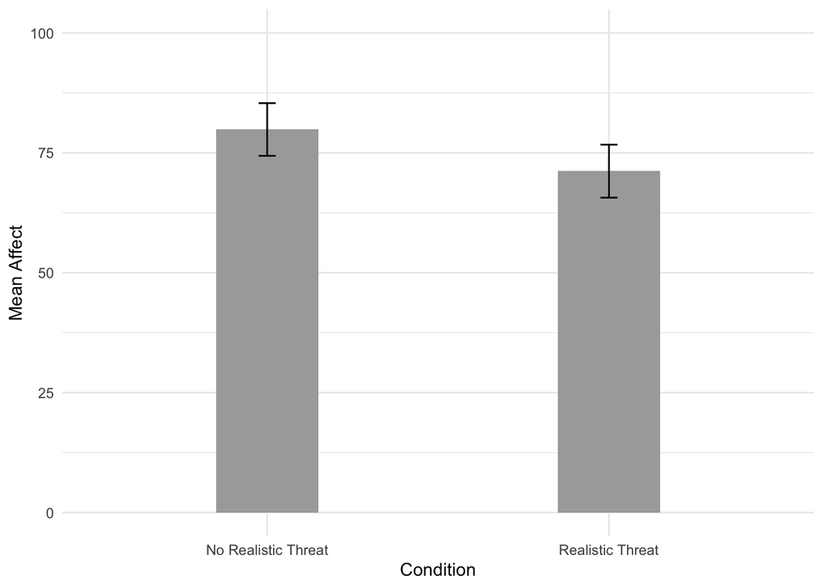

```r
# Prep for data visualization
filtered_data %>%
  group_by(Condition) %>%
  filter(!is.na(Condition)) %>%
  summarise(M = mean(emotion),
            SD = sd(emotion),
            count = n(),
            ci_affect = 1.96 * sd(emotion) / sqrt(count)) -> mean_affect

# Bar graph
ggplot(data = mean_affect, aes(x=Condition, y=M, ymin=M-ci_affect, ymax= M+ci_affect)) +
  geom_bar(stat = "identity", width = 0.3, fill="darkgrey") +
  geom_errorbar(width = 0.05) +
  coord_cartesian(ylim = c(0,100)) +
  ylab("Mean Affect") +
  xlab("Condition") +
  theme_minimal()
```

### Confirmatory analysis

The bar graph on the top (Figure 4 in the paper) shows the results from the original study. Note that the y-axis is truncated on this graph, so it does not display the full 0 to 100 scale. The bar graph on the bottom shows the results from my replication study.

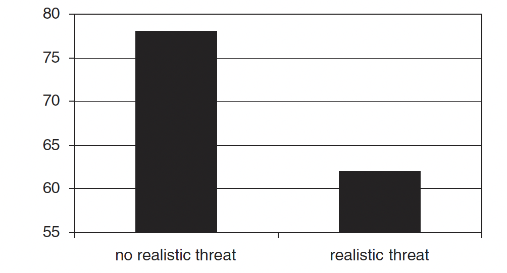

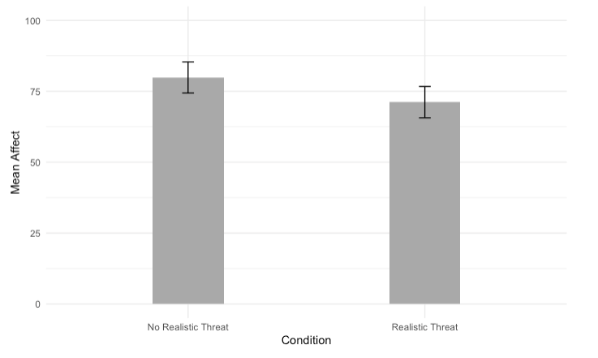

### Exploratory analyses

The original study also found that attitude toward Asian Americans was more negative in the realistic threat condition. Although this was not the key finding I chose to replicate, I wanted to see if this finding was consistent in my replication.

```
##             Df Sum Sq Mean Sq F value Pr(>F)
## Condition    1   2.31   2.306   1.564  0.215
## Residuals   75 110.58   1.474
```

```
##               eta.sq eta.sq.part
## Condition 0.02042993  0.02042993
```

## Discussion

### Summary of Replication Attempt

I was able to fully replicate the significance of this difference, but the finding is not as robust as the original, as reflected in the weaker evidence shown in the *p* values and *F* values. The figure I produced from the replication also looks qualitatively similar to the original, but the original did not provide error bars or discuss standard error of the mean or confidence intervals, so I’m not entirely sure how similar the figures are in terms of data variability.